# Descriptive Analytics Project

Chenxi He

2024-04-17

## 1. Dataset Selection

The data set used in this project describes the performance evaluation of cars produced by Japanese, American, and European manufacturers. The entire dataset is obtained from [UCI database](https://archive.ics.uci.edu/dataset/9/auto+mpg). According to the website, we can learn that the data set is taken from the StatLib library maintained by Carnegie Mellon University. This data set was used at the 1983 American Statistical Association Exposition. This dataset is often used for example and model-based learning. Therefore, this data set is very friendly to beginners due to its simple structure. Therefore, this project will combine the knowledge learned to mine the information contained in this data set.

In addition, from the information given on the website, the data set contains nine features. The names, descriptions and variable types of these nine features (variables) are shown in the table below. From the information in the table, we can find that these nine variables include five continuous variables, three integer variables and one discrete variable. Although the variable `origin` is an integer value, it is actually a discrete variable. In addition, the variable `car name` can be understood as the ID of the vehicle. It is pointless to study this variable.

```r
library(knitr)
library(kableExtra)
library(magrittr)
read.table(text = '
Variable; Description; Type
mpg; Miles/(US) gallon; Continuous
cylinders; number of cylinders; Integer
displacement; displacement (cu.in.); Continuous
horsepower; gross horsepower; Continuous
weight; weight (1000 lbs); Continuous
acceleration; car acceleration ability (1/4 mile time); Continuous
model year; year of production of the car; Integer
origin; the country/region of origin or manufacture of the car; Integer
car name; car name or model; Categorical', header = T, sep = ';') %>%
  kable %>%
  kable_classic(full_width = F, html_font = 'Cambria')
```

| Variable | Description | Type |
| --- | --- | --- |
| mpg | Miles/(US) gallon | Continuous |
| cylinders | number of cylinders | Integer |
| displacement | displacement (cu.in.) | Continuous |
| horsepower | gross horsepower | Continuous |
| weight | weight (1000 lbs) | Continuous |
| acceleration | car acceleration ability (1/4 mile time) | Continuous |
| model year | year of production of the car | Integer |
| origin | the country/region of origin or manufacture of the car | Integer |
| car name | car name or model | Categorical |

Here, I read the data set, which does not contain variable names and needs to be specified. The first six rows of the entire data set are shown in the output below.

```r
df_raw <- read.table('auto-mpg.data')
colnames(df_raw) <- c('mpg', 'cylinders', 'displacement', 'horsepower', 'weight',
                  'acceleration', 'model year', 'origin', 'car name')
head(df_raw) %>%
  kable %>%
  kable_classic(full_width = F, html_font = 'Cambria')
```

| mpg | cylinders | displacement | horsepower | weight | acceleration | model year | origin | car name |
| --- | --- | --- | --- | --- | --- | --- | --- | --- |
| 18 | 8 | 307 | 130.0 | 3504 | 12.0 | 70 | 1 | chevrolet chevelle malibu |
| 15 | 8 | 350 | 165.0 | 3693 | 11.5 | 70 | 1 | buick skylark 320 |
| 18 | 8 | 318 | 150.0 | 3436 | 11.0 | 70 | 1 | plymouth satellite |
| 16 | 8 | 304 | 150.0 | 3433 | 12.0 | 70 | 1 | amc rebel sst |
| 17 | 8 | 302 | 140.0 | 3449 | 10.5 | 70 | 1 | ford torino |
| 15 | 8 | 429 | 198.0 | 4341 | 10.0 | 70 | 1 | ford galaxie 500 |

## 2. Data Cleaning

In data analysis, although 8 and ‘8’ both look like 8, the former is a number and the latter is a character. Therefore, for us, when importing data, the most important thing is to check whether the types and descriptions of variables in the data are consistent. Here I check the variable type. From the results, we can find that the variable `horsepower` is of character type and does not match the description. So I need to change that variable from character type to numeric type. After processing, the variable type of the data is consistent with the description.

```r
str(df_raw)
```

```
## 'data.frame':    398 obs. of  9 variables:
##  $ mpg         : num  18 15 18 16 17 15 14 14 14 15 ...
##  $ cylinders   : int  8 8 8 8 8 8 8 8 8 8 ...
##  $ displacement: num  307 350 318 304 302 429 454 440 455 390 ...
##  $ horsepower  : chr  "130.0" "165.0" "150.0" "150.0" ...
##  $ weight      : num  3504 3693 3436 3433 3449 ...
##  $ acceleration: num  12 11.5 11 12 10.5 10 9 8.5 10 8.5 ...
##  $ model year  : int  70 70 70 70 70 70 70 70 70 70 ...
##  $ origin      : int  1 1 1 1 1 1 1 1 1 1 ...
##  $ car name    : chr  "chevrolet chevelle malibu" "buick skylark 320" "plymouth satellite" "amc rebel sst" ...
```

```r
df <- df_raw
df$horsepower <- as.numeric(df$horsepower)
str(df)
```

```
## 'data.frame':    398 obs. of  9 variables:
##  $ mpg         : num  18 15 18 16 17 15 14 14 14 15 ...
##  $ cylinders   : int  8 8 8 8 8 8 8 8 8 8 ...
##  $ displacement: num  307 350 318 304 302 429 454 440 455 390 ...
##  $ horsepower  : num  130 165 150 150 140 198 220 215 225 190 ...
##  $ weight      : num  3504 3693 3436 3433 3449 ...
##  $ acceleration: num  12 11.5 11 12 10.5 10 9 8.5 10 8.5 ...
##  $ model year  : int  70 70 70 70 70 70 70 70 70 70 ...
##  $ origin      : int  1 1 1 1 1 1 1 1 1 1 ...
##  $ car name    : chr  "chevrolet chevelle malibu" "buick skylark 320" "plymouth satellite" "amc rebel sst" ...
```

Next, I started by checking whether the data contained missing values. It can be found from the results that except for the variable `horsepower` which contains 6 missing value records, other variables do not contain missing records. In total, 6 vehicle information in the entire data set contains missing records, with a missing ratio of 1.5%. Considering that the missing ratio of the entire data set is very low, here I will delete these vehicle information with missing information.

```r
sapply(df, FUN = function(x) sum(is.na(x)))
```

```
##          mpg    cylinders displacement   horsepower       weight acceleration
##            0            0            0            6            0            0
##   model year       origin     car name
##            0            0            0
```

```r
sum(is.na(df))
```

```
## [1] 6
```

```r
sum(is.na(df))/nrow(df)
```

```
## [1] 0.01507538
```

```r
df <- na.omit(df)
```

In data analysis, outliers refer to extreme values that are significantly different from other observed values in the data set. They can be due to measurement error, data entry errors, sample bias, or real extreme situations. Outliers can have an impact on the descriptive statistics of your data, such as mean and standard deviation. For continuous variables, we generally identify them based on box plots and standard deviations. Both methods are based on the basis of the normal distribution. Here, I first observe the histogram of these 5 continuous variables. From the results of the histogram, it can be found that the variables `displacement` and `horsepower` exhibit a severely right-skewed distribution. In other words, there are some extremely large records for these two variables that can easily be identified as outliers.

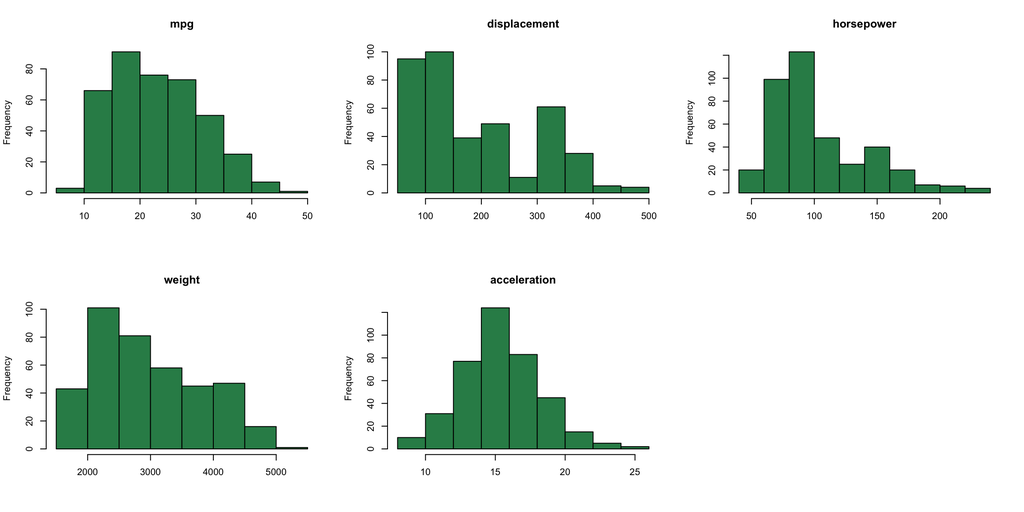

```r
par(mfrow = c(2, 3))
hist(df$mpg, col = 'seagreen',  main = 'mpg', xlab = '')
hist(df$displacement, col = 'seagreen', main = 'displacement', xlab = '')
hist(df$horsepower, col = 'seagreen',   main = 'horsepower', xlab = '')
hist(df$weight, col = 'seagreen',  main = 'weight', xlab = '')
hist(df$acceleration, col = 'seagreen',  main = 'acceleration', xlab = '')
```

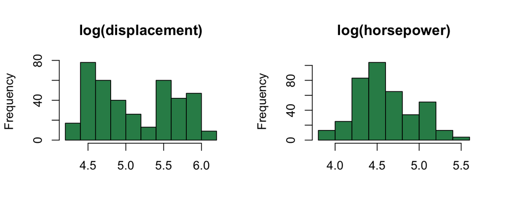

```r
par(mfrow = c(1, 2))
hist(log(df$displacement), main = 'log(displacement)', xlab = '', col = 'seagreen')
hist(log(df$horsepower), main = 'log(horsepower)', xlab = '', col = 'seagreen')
```

Boxplots can show the distribution of data and outliers. Outliers are typically defined as data points that fall outside the “whiskers” of a boxplot. Outliers in continuous variables can be initially identified by examining outliers in boxplots. It can be found from the figure that the variables `acceleration` have outliers.

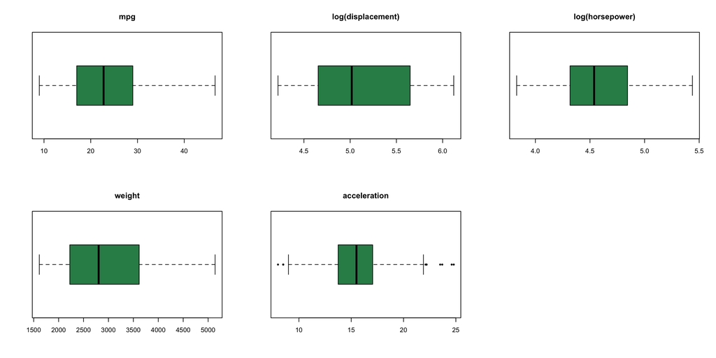

```r
par(mfrow = c(2, 3))
boxplot(df$mpg, col = 'seagreen', pch = 16, horizontal = T, main = 'mpg')
boxplot(log(df$displacement), col = 'seagreen', pch = 16, horizontal = T, main = 'log(displacement)')
boxplot(log(df$horsepower), col = 'seagreen', pch = 16, horizontal = T, main = 'log(horsepower)')
boxplot(df$weight, col = 'seagreen', pch = 16, horizontal = T, main = 'weight')
boxplot(df$acceleration, col = 'seagreen', pch = 16, horizontal = T, main = 'acceleration')
```

The standard deviation-based method means that by calculating the mean and standard deviation of the data, data points that are far away from the mean can be identified. Generally speaking, observations outside the range of more than 3 times the standard deviation are considered outliers. Here, I wrote a function to identify possible outliers in five continuous variables. It can be found from the results that there are 2 outliers in the variable `acceleration`.

```r
get_outliers <- function(x){
  x <- x[x < (mean(x) - 3*sd(x))|x > (mean(x) + 3*sd(x))]
  if(length(x) == 0){
    print('No outliers')
  }else{
    return(x)
  }
}

get_outliers(df$mpg)
```

```
## [1] "No outliers"
```

```r
get_outliers(log(df$displacement))
```

```
## [1] "No outliers"
```

```r
get_outliers(log(df$horsepower))
```

```
## [1] "No outliers"
```

```r
get_outliers(df$weight)
```

```
## [1] "No outliers"
```

```r
get_outliers(df$acceleration)
```

```
## [1] 24.8 24.6
```

Based on the above analysis, I will delete the two records with values 24.8 and 24.6 in the variable `acceleration` variable, because both methods consider these two values to be outliers.

```r
df <- df[df$acceleration  < 24.6, ]
```

For integer data, the identification of outliers is mainly based on the definition of the data. The variable `cylinders` describes the number of cylinders in the engine. The bar graph shows that the number of cylinders in the engines of the cars included in the data set is mainly 5 types: 3, 4, 5, 6 and 8. All five types of cylinder counts are common, so I don’t think there are outliers on this variable. The variable `origin` indicates the origin of the car, and the data set contains three different origins. Therefore, I don’t think the variable `origin` has an outlier. Other variables are unimportant and the information they contain has no impact on the quality of the data set. Therefore, this item will not be discussed.

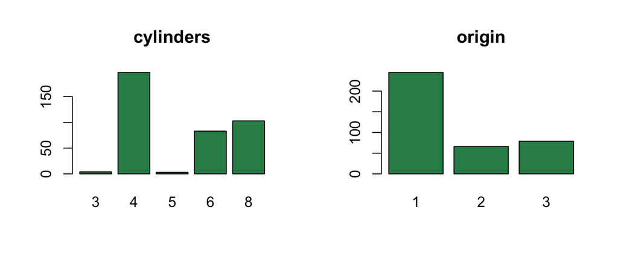

```r
par(mfrow = c(1, 2))
barplot(table(df$cylinders), main = 'cylinders', col = 'seagreen')
barplot(table(df$origin), main = 'origin', col = 'seagreen')
```

Based on the above processing, this project obtained relatively clean data. Next, this project will further process the data to conduct exploratory analysis.

## 3. Data Handling

Although the variables `model year` and `car name` provide some other information about the car and are important for retrieving the vehicle, they have no meaning for comparing car performance. Here I delete these two variables. The final data I got contains 7 columns and 390 rows. Each column represents a different car feature, and each row represents information about a different car. Additionally, I double-checked the type of the variable in the data and found that it is consistent with the description.

```r
df <- df[, -c(7, 9)]
dim(df)
```

```
## [1] 390   7
```

```r
str(df)
```

```
## 'data.frame':    390 obs. of  7 variables:
##  $ mpg         : num  18 15 18 16 17 15 14 14 14 15 ...
##  $ cylinders   : int  8 8 8 8 8 8 8 8 8 8 ...
##  $ displacement: num  307 350 318 304 302 429 454 440 455 390 ...
##  $ horsepower  : num  130 165 150 150 140 198 220 215 225 190 ...
##  $ weight      : num  3504 3693 3436 3433 3449 ...
##  $ acceleration: num  12 11.5 11 12 10.5 10 9 8.5 10 8.5 ...
##  $ origin      : int  1 1 1 1 1 1 1 1 1 1 ...
```

Although the variables `cylinders` and `origin` are integer data. However, the former can be compared in size, while the latter indicates different origins and cannot be compared in size. So the variable `origin` is actually a discrete variable, so I need to change it from a numeric variable to a factor variable. In addition, we know from the previous analysis that the variables `horsepower` and `displacement` show a severely right-skewed distribution, and I need to take the logarithm of it to reduce the skewness of the data.

```r
library(dplyr)
df <- mutate(df,
             origin = factor(origin, levels = 1:3, labels = c('USA', 'Europe', 'Japan')),
             horsepower = log(horsepower),
             displacement = log(displacement))
colnames(df)[3:4] <- c('log(displacement)', 'log(horsepower)')
```

To have a clear understanding of the processed data, I summarize the data here, and the summary results are shown in the output below. From the results, it can be found that of the 390 cars included in the entire data, 245 were produced in the United States, 66 were produced in Europe, and 79 were produced in Japan. In addition, the summary information also displays statistics such as the mean, minimum, maximum, and quartiles of each feature. With this information, we can get a general idea of the performance of the vehicles recorded in the data. For example, the variable `cylinders` has a mean of 5.47 and a median of 4. The mean is greater than the median, which means that more than half of the cars recorded in the data set have less than 5 cylinders.

```r
summary(df)
```

```
##       mpg          cylinders     log(displacement) log(horsepower)
##  Min.   : 9.00   Min.   :3.000   Min.   :4.220     Min.   :3.829
##  1st Qu.:17.00   1st Qu.:4.000   1st Qu.:4.654     1st Qu.:4.331
##  Median :22.45   Median :4.000   Median :5.017     Median :4.549
##  Mean   :23.38   Mean   :5.479   Mean   :5.130     Mean   :4.590
##  3rd Qu.:29.00   3rd Qu.:8.000   3rd Qu.:5.680     3rd Qu.:4.852
##  Max.   :46.60   Max.   :8.000   Max.   :6.120     Max.   :5.438
##      weight      acceleration      origin
##  Min.   :1613   Min.   : 8.00   USA   :245
##  1st Qu.:2226   1st Qu.:13.72   Europe: 66
##  Median :2804   Median :15.50   Japan : 79
##  Mean   :2979   Mean   :15.49
##  3rd Qu.:3618   3rd Qu.:17.00
##  Max.   :5140   Max.   :23.70
```

## 4. Descriptive Analysis

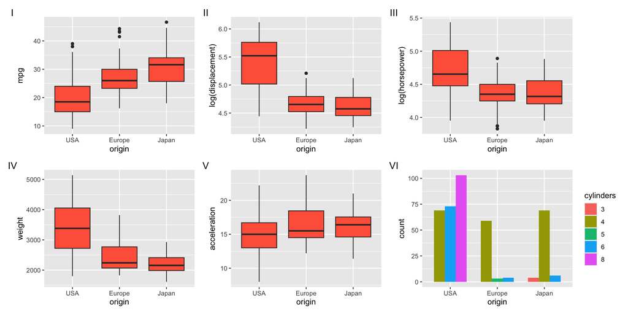

```r
library(ggplot2)
p1 <- ggplot(df, aes(x = origin, y = mpg)) +
  geom_boxplot(fill = 'tomato')

p2 <- ggplot(df, aes(x = origin, y = `log(displacement)`)) +
  geom_boxplot(fill = 'tomato')

p3 <- ggplot(df, aes(x = origin, y = `log(horsepower)`)) +
  geom_boxplot(fill = 'tomato')

p4 <- ggplot(df, aes(x = origin, y = weight)) +
  geom_boxplot(fill = 'tomato')

p5 <- ggplot(df, aes(x = origin, y = acceleration)) +
  geom_boxplot(fill = 'tomato')

p6 <- df %>% group_by(origin, cylinders) %>%
  count %>%
  ggplot(aes(x = origin, fill = factor(cylinders), y = n)) +
  geom_bar(stat = 'identity', position = position_dodge(0.7), width = 0.7) +
  labs(fill = 'cylinders', y = 'count')
library(patchwork)
p1 + p2 + p3 + p4 + p5 + p6 +
  plot_layout(ncol = 3) + plot_annotation(tag_levels = 'I')
```

To facilitate readers to conduct more detailed and in-depth comparison and analysis, I calculated the minimum value, maximum value, mean, median and standard deviation of each feature of the total car. At the same time, I also performed related calculations on the statistics of these characteristics of cars from each origin. The results are summarized below.

```r
rbind(data.frame(Class = 'Overall',
           do.call(rbind, lapply(df[, - 7], FUN = function(x){
  data.frame(min = min(x), mean = round(mean(x), 2), median = median(x), `standard deviation` = round(sd(x), 2), max = max(x))
})) ),
data.frame(Class = 'USA',
           do.call(rbind, lapply(df[df$origin == 'USA', - 7], FUN = function(x){
  data.frame(min = min(x), mean = round(mean(x), 2), median = median(x), `standard deviation` = round(sd(x), 2), max = max(x))
})) ),
data.frame(Class = 'Europe',
           do.call(rbind, lapply(df[df$origin == 'Europe', - 7], FUN = function(x){
  data.frame(min = min(x), mean = round(mean(x), 2), median = median(x), `standard deviation` = round(sd(x), 2), max = max(x))
})) ),
data.frame(Class = 'Japan',
           do.call(rbind, lapply(df[df$origin == 'Japan', - 7], FUN = function(x){
  data.frame(min = min(x), mean = round(mean(x), 2), median = median(x), `standard deviation` = round(sd(x), 2), max = max(x))
})) )
) %>%
  kable(digits = 2) %>%
  kable_classic(full_width = F, html_font = 'Cambria')
```

|  | Class | min | mean | median | standard.deviation | max |
| --- | --- | --- | --- | --- | --- | --- |
| mpg | Overall | 9.00 | 23.38 | 22.45 | 7.75 | 46.60 |
| cylinders | Overall | 3.00 | 5.48 | 4.00 | 1.71 | 8.00 |
| log(displacement) | Overall | 4.22 | 5.13 | 5.02 | 0.53 | 6.12 |
| log(horsepower) | Overall | 3.83 | 4.59 | 4.55 | 0.34 | 5.44 |
| weight | Overall | 1613.00 | 2979.21 | 2803.50 | 850.43 | 5140.00 |
| acceleration | Overall | 8.00 | 15.49 | 15.50 | 2.69 | 23.70 |
| mpg1 | USA | 9.00 | 20.03 | 18.50 | 6.44 | 39.00 |
| cylinders1 | USA | 4.00 | 6.28 | 6.00 | 1.66 | 8.00 |
| log(displacement)1 | USA | 4.44 | 5.42 | 5.52 | 0.45 | 6.12 |
| log(horsepower)1 | USA | 3.95 | 4.73 | 4.65 | 0.32 | 5.44 |
| weight1 | USA | 1800.00 | 3372.49 | 3381.00 | 795.35 | 5140.00 |
| acceleration1 | USA | 8.00 | 14.99 | 15.00 | 2.74 | 22.20 |
| mpg2 | Europe | 16.20 | 27.36 | 26.00 | 6.36 | 44.30 |
| cylinders2 | Europe | 4.00 | 4.17 | 4.00 | 0.51 | 6.00 |
| log(displacement)2 | Europe | 4.22 | 4.67 | 4.65 | 0.20 | 5.21 |
| log(horsepower)2 | Europe | 3.83 | 4.37 | 4.35 | 0.25 | 4.89 |
| weight2 | Europe | 1825.00 | 2426.61 | 2240.00 | 488.93 | 3820.00 |
| acceleration2 | Europe | 12.20 | 16.55 | 15.50 | 2.80 | 23.70 |
| mpg3 | Japan | 18.00 | 30.45 | 31.60 | 6.09 | 46.60 |
| cylinders3 | Japan | 3.00 | 4.10 | 4.00 | 0.59 | 6.00 |
| log(displacement)3 | Japan | 4.25 | 4.61 | 4.57 | 0.21 | 5.12 |
| log(horsepower)3 | Japan | 3.95 | 4.36 | 4.32 | 0.22 | 4.88 |
| weight3 | Japan | 1613.00 | 2221.23 | 2155.00 | 320.50 | 2930.00 |
| acceleration3 | Japan | 11.40 | 16.17 | 16.40 | 1.95 | 21.00 |

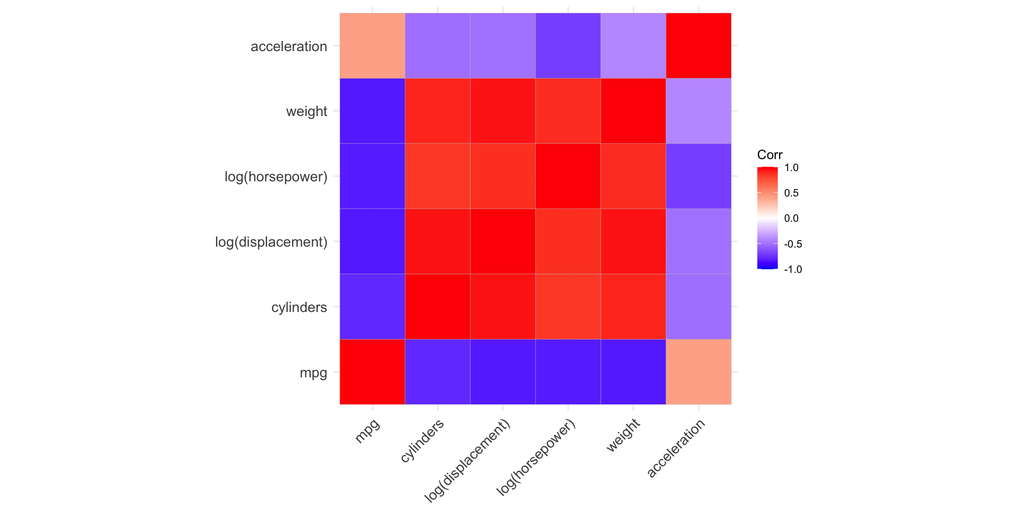

```r
library('corrr')
library("ggcorrplot")
library("FactoMineR")
library("devtools")
library("factoextra")

corr_matrix <- cor(df[,-7])
ggcorrplot(corr_matrix)
```

Next, I perform dimensionality reduction analysis using principal components. From the results of principal component analysis, it can be found that the first two principal components can explain 90% of the fluctuations in the original data. Then, I visualized the loading matrix from the principal component analysis. It can be found from the figure that the first principal component can well explain the variables `weight`, `displacement`, `cylinders`, `horsepower` and `mpg`, while the second principal component mainly explains the variable `acdeleration` . This implies that the first principal component is mainly related to the power system of the car. The more powerful the car, the higher the fuel consumption. The second principal component is related to acceleration. In addition, I also drew a scatter plot of different cars based on principal component scores. From the figure, we can find that cars made in the United States have lower first principal component scores, while cars made in Europe and Japan have higher scores. First principal component score. But their differences in the second principal component scores are not significant.

```r
data.pca <- princomp(apply(df[,-7], 2, scale))
summary(data.pca)
```

```
## Importance of components:
##                           Comp.1    Comp.2     Comp.3     Comp.4      Comp.5
## Standard deviation     2.1873567 0.8603806 0.49699644 0.34108236 0.234958525
## Proportion of Variance 0.7994715 0.1236929 0.04127341 0.01943937 0.009224571
## Cumulative Proportion  0.7994715 0.9231644 0.96443784 0.98387721 0.993101781
##                             Comp.6
## Standard deviation     0.203182652
## Proportion of Variance 0.006898219
## Cumulative Proportion  1.000000000
```

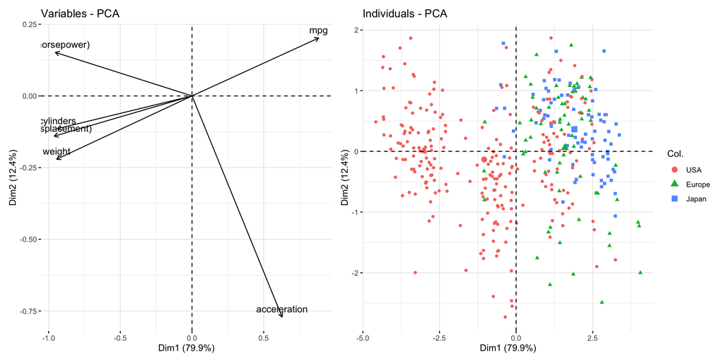

```r
p1 <- fviz_pca_var(data.pca, col.var = "black")

p2 <- fviz_pca_ind(data.pca, geom = 'point', col.ind = df$origin)
p1 + p2
```